# heartdisease_eda

### About data set

A cardiac tumor is an abnormal growth of tissue in the heart classified as either cancerous (malignant) or non-cancerous (benign).

### Importing libraries

```python
import numpy as np
import pandas as pd
import matplotlib.pyplot as plt
import seaborn as sns
```

### Adding csv file

```python
data=pd.read_csv('heart.csv')
```

### Basic information about dataset

```python
data
```

|  | age | sex | cp | trestbps | chol | fbs | restecg | thalach | exang | oldpeak | slope | ca | thal | target |
| --- | --- | --- | --- | --- | --- | --- | --- | --- | --- | --- | --- | --- | --- | --- |
| 0 | 52 | 1 | 0 | 125 | 212 | 0 | 1 | 168 | 0 | 1.0 | 2 | 2 | 3 | 0 |
| 1 | 53 | 1 | 0 | 140 | 203 | 1 | 0 | 155 | 1 | 3.1 | 0 | 0 | 3 | 0 |
| 2 | 70 | 1 | 0 | 145 | 174 | 0 | 1 | 125 | 1 | 2.6 | 0 | 0 | 3 | 0 |
| 3 | 61 | 1 | 0 | 148 | 203 | 0 | 1 | 161 | 0 | 0.0 | 2 | 1 | 3 | 0 |
| 4 | 62 | 0 | 0 | 138 | 294 | 1 | 1 | 106 | 0 | 1.9 | 1 | 3 | 2 | 0 |
| ... | ... | ... | ... | ... | ... | ... | ... | ... | ... | ... | ... | ... | ... | ... |
| 1020 | 59 | 1 | 1 | 140 | 221 | 0 | 1 | 164 | 1 | 0.0 | 2 | 0 | 2 | 1 |
| 1021 | 60 | 1 | 0 | 125 | 258 | 0 | 0 | 141 | 1 | 2.8 | 1 | 1 | 3 | 0 |
| 1022 | 47 | 1 | 0 | 110 | 275 | 0 | 0 | 118 | 1 | 1.0 | 1 | 1 | 2 | 0 |
| 1023 | 50 | 0 | 0 | 110 | 254 | 0 | 0 | 159 | 0 | 0.0 | 2 | 0 | 2 | 1 |
| 1024 | 54 | 1 | 0 | 120 | 188 | 0 | 1 | 113 | 0 | 1.4 | 1 | 1 | 3 | 0 |

1025 rows × 14 columns

```python
data.shape
```

```
(1025, 14)
```

```python
data.info()
```

```
<class 'pandas.core.frame.DataFrame'>
RangeIndex: 1025 entries, 0 to 1024
Data columns (total 14 columns):
 #   Column    Non-Null Count  Dtype
---  ------    --------------  -----
 0   age       1025 non-null   int64
 1   sex       1025 non-null   int64
 2   cp        1025 non-null   int64
 3   trestbps  1025 non-null   int64
 4   chol      1025 non-null   int64
 5   fbs       1025 non-null   int64
 6   restecg   1025 non-null   int64
 7   thalach   1025 non-null   int64
 8   exang     1025 non-null   int64
 9   oldpeak   1025 non-null   float64
 10  slope     1025 non-null   int64
 11  ca        1025 non-null   int64
 12  thal      1025 non-null   int64
 13  target    1025 non-null   int64
dtypes: float64(1), int64(13)
memory usage: 112.2 KB
```

```python
data.describe()
```

|  | age | sex | cp | trestbps | chol | fbs | restecg | thalach | exang | oldpeak | slope | ca | thal | target |
| --- | --- | --- | --- | --- | --- | --- | --- | --- | --- | --- | --- | --- | --- | --- |
| count | 1025.000000 | 1025.000000 | 1025.000000 | 1025.000000 | 1025.00000 | 1025.000000 | 1025.000000 | 1025.000000 | 1025.000000 | 1025.000000 | 1025.000000 | 1025.000000 | 1025.000000 | 1025.000000 |
| mean | 54.434146 | 0.695610 | 0.942439 | 131.611707 | 246.00000 | 0.149268 | 0.529756 | 149.114146 | 0.336585 | 1.071512 | 1.385366 | 0.754146 | 2.323902 | 0.513171 |
| std | 9.072290 | 0.460373 | 1.029641 | 17.516718 | 51.59251 | 0.356527 | 0.527878 | 23.005724 | 0.472772 | 1.175053 | 0.617755 | 1.030798 | 0.620660 | 0.500070 |
| min | 29.000000 | 0.000000 | 0.000000 | 94.000000 | 126.00000 | 0.000000 | 0.000000 | 71.000000 | 0.000000 | 0.000000 | 0.000000 | 0.000000 | 0.000000 | 0.000000 |
| 25% | 48.000000 | 0.000000 | 0.000000 | 120.000000 | 211.00000 | 0.000000 | 0.000000 | 132.000000 | 0.000000 | 0.000000 | 1.000000 | 0.000000 | 2.000000 | 0.000000 |
| 50% | 56.000000 | 1.000000 | 1.000000 | 130.000000 | 240.00000 | 0.000000 | 1.000000 | 152.000000 | 0.000000 | 0.800000 | 1.000000 | 0.000000 | 2.000000 | 1.000000 |
| 75% | 61.000000 | 1.000000 | 2.000000 | 140.000000 | 275.00000 | 0.000000 | 1.000000 | 166.000000 | 1.000000 | 1.800000 | 2.000000 | 1.000000 | 3.000000 | 1.000000 |
| max | 77.000000 | 1.000000 | 3.000000 | 200.000000 | 564.00000 | 1.000000 | 2.000000 | 202.000000 | 1.000000 | 6.200000 | 2.000000 | 4.000000 | 3.000000 | 1.000000 |

```python
data.head()
```

|  | age | sex | cp | trestbps | chol | fbs | restecg | thalach | exang | oldpeak | slope | ca | thal | target |
| --- | --- | --- | --- | --- | --- | --- | --- | --- | --- | --- | --- | --- | --- | --- |
| 0 | 52 | 1 | 0 | 125 | 212 | 0 | 1 | 168 | 0 | 1.0 | 2 | 2 | 3 | 0 |
| 1 | 53 | 1 | 0 | 140 | 203 | 1 | 0 | 155 | 1 | 3.1 | 0 | 0 | 3 | 0 |
| 2 | 70 | 1 | 0 | 145 | 174 | 0 | 1 | 125 | 1 | 2.6 | 0 | 0 | 3 | 0 |
| 3 | 61 | 1 | 0 | 148 | 203 | 0 | 1 | 161 | 0 | 0.0 | 2 | 1 | 3 | 0 |
| 4 | 62 | 0 | 0 | 138 | 294 | 1 | 1 | 106 | 0 | 1.9 | 1 | 3 | 2 | 0 |

```python
data.tail()
```

|  | age | sex | cp | trestbps | chol | fbs | restecg | thalach | exang | oldpeak | slope | ca | thal | target |
| --- | --- | --- | --- | --- | --- | --- | --- | --- | --- | --- | --- | --- | --- | --- |
| 1020 | 59 | 1 | 1 | 140 | 221 | 0 | 1 | 164 | 1 | 0.0 | 2 | 0 | 2 | 1 |
| 1021 | 60 | 1 | 0 | 125 | 258 | 0 | 0 | 141 | 1 | 2.8 | 1 | 1 | 3 | 0 |
| 1022 | 47 | 1 | 0 | 110 | 275 | 0 | 0 | 118 | 1 | 1.0 | 1 | 1 | 2 | 0 |
| 1023 | 50 | 0 | 0 | 110 | 254 | 0 | 0 | 159 | 0 | 0.0 | 2 | 0 | 2 | 1 |
| 1024 | 54 | 1 | 0 | 120 | 188 | 0 | 1 | 113 | 0 | 1.4 | 1 | 1 | 3 | 0 |

```python
data.sample(10)
```

|  | age | sex | cp | trestbps | chol | fbs | restecg | thalach | exang | oldpeak | slope | ca | thal | target |
| --- | --- | --- | --- | --- | --- | --- | --- | --- | --- | --- | --- | --- | --- | --- |
| 393 | 62 | 0 | 0 | 160 | 164 | 0 | 0 | 145 | 0 | 6.2 | 0 | 3 | 3 | 0 |
| 929 | 60 | 1 | 0 | 130 | 206 | 0 | 0 | 132 | 1 | 2.4 | 1 | 2 | 3 | 0 |
| 736 | 59 | 1 | 0 | 110 | 239 | 0 | 0 | 142 | 1 | 1.2 | 1 | 1 | 3 | 0 |
| 700 | 41 | 1 | 2 | 130 | 214 | 0 | 0 | 168 | 0 | 2.0 | 1 | 0 | 2 | 1 |
| 106 | 51 | 1 | 0 | 140 | 299 | 0 | 1 | 173 | 1 | 1.6 | 2 | 0 | 3 | 0 |
| 696 | 50 | 0 | 2 | 120 | 219 | 0 | 1 | 158 | 0 | 1.6 | 1 | 0 | 2 | 1 |
| 632 | 45 | 0 | 1 | 130 | 234 | 0 | 0 | 175 | 0 | 0.6 | 1 | 0 | 2 | 1 |
| 915 | 46 | 1 | 0 | 120 | 249 | 0 | 0 | 144 | 0 | 0.8 | 2 | 0 | 3 | 0 |
| 371 | 55 | 1 | 0 | 132 | 353 | 0 | 1 | 132 | 1 | 1.2 | 1 | 1 | 3 | 0 |
| 1011 | 45 | 1 | 1 | 128 | 308 | 0 | 0 | 170 | 0 | 0.0 | 2 | 0 | 2 | 1 |

```python
data.columns
```

```
Index(['age', 'sex', 'cp', 'trestbps', 'chol', 'fbs', 'restecg', 'thalach',
       'exang', 'oldpeak', 'slope', 'ca', 'thal', 'target'],
      dtype='object')
```

### information about columns

#### 1.sex-

0 represents female whereas 1 represents male

#### 2.trestbps(Resting blood pressure )-

High blood pressure = 140 mmHg or above

#### 3.chol(Serum cholestoral)-

Higher than 200 mg/dL is concerned

#### 4.fbs(Fasting blood sugar)-

0 represents < 120 mg/dL whereas 1 represents > 120 mg/dL Higher than 126 mg/dL points to diabetes

#### 5.thalach-

Maximum heart rate achieved (bpm)

#### 6.exang(Exercise induced angina)

0:Negative 1: Positive

#### 7.oldpeak-

ST depression induced by exercise relative to rest

#### 8.ca-

Number of major vessels (0-3) colored by fluoroscopy There is a clot if the blood vessel is not colored

#### 9.target( Heart Disease)

0 :Benign 1 :Malignant

```python
data.dtypes
```

```
age           int64
sex           int64
cp            int64
trestbps      int64
chol          int64
fbs           int64
restecg       int64
thalach       int64
exang         int64
oldpeak     float64
slope         int64
ca            int64
thal          int64
target        int64
dtype: object
```

### checking for incomplete and duplicate data

```python
data.isnull().sum()
```

```
age         0
sex         0
cp          0
trestbps    0
chol        0
fbs         0
restecg     0
thalach     0
exang       0
oldpeak     0
slope       0
ca          0
thal        0
target      0
dtype: int64
```

```python
copy=data.duplicated().sum()
copy
```

```
723
```

### Removing duplicate data

```python
data = data.drop_duplicates()
```

```python
data
```

|  | age | sex | cp | trestbps | chol | fbs | restecg | thalach | exang | oldpeak | slope | ca | thal | target |
| --- | --- | --- | --- | --- | --- | --- | --- | --- | --- | --- | --- | --- | --- | --- |
| 0 | 52 | 1 | 0 | 125 | 212 | 0 | 1 | 168 | 0 | 1.0 | 2 | 2 | 3 | 0 |
| 1 | 53 | 1 | 0 | 140 | 203 | 1 | 0 | 155 | 1 | 3.1 | 0 | 0 | 3 | 0 |
| 2 | 70 | 1 | 0 | 145 | 174 | 0 | 1 | 125 | 1 | 2.6 | 0 | 0 | 3 | 0 |
| 3 | 61 | 1 | 0 | 148 | 203 | 0 | 1 | 161 | 0 | 0.0 | 2 | 1 | 3 | 0 |
| 4 | 62 | 0 | 0 | 138 | 294 | 1 | 1 | 106 | 0 | 1.9 | 1 | 3 | 2 | 0 |
| ... | ... | ... | ... | ... | ... | ... | ... | ... | ... | ... | ... | ... | ... | ... |
| 723 | 68 | 0 | 2 | 120 | 211 | 0 | 0 | 115 | 0 | 1.5 | 1 | 0 | 2 | 1 |
| 733 | 44 | 0 | 2 | 108 | 141 | 0 | 1 | 175 | 0 | 0.6 | 1 | 0 | 2 | 1 |
| 739 | 52 | 1 | 0 | 128 | 255 | 0 | 1 | 161 | 1 | 0.0 | 2 | 1 | 3 | 0 |
| 843 | 59 | 1 | 3 | 160 | 273 | 0 | 0 | 125 | 0 | 0.0 | 2 | 0 | 2 | 0 |
| 878 | 54 | 1 | 0 | 120 | 188 | 0 | 1 | 113 | 0 | 1.4 | 1 | 1 | 3 | 0 |

302 rows × 14 columns

```python
data.shape
```

```
(302, 14)
```

## Data Analysis

### 1.male to female ratio

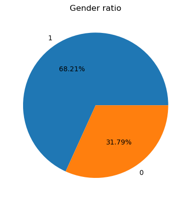

```python
gender=data.sex.value_counts()
plt.pie(gender,labels=gender.index,autopct='%1.2f%%')
plt.title('Gender ratio')
plt.show()
```

```python
gender
```

```
sex
1    206
0     96
Name: count, dtype: int64
```

### 2.benign to malignant ratio

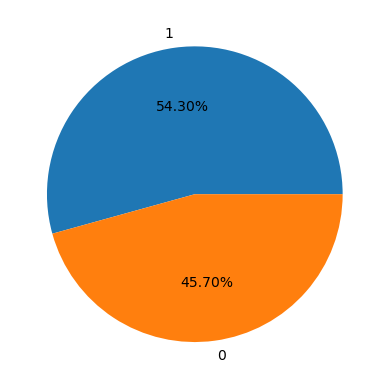

```python
disease_ratio=data.target.value_counts()
plt.pie(disease_ratio,labels=disease_ratio.index,autopct='%1.2f%%')
plt.show()
```

### 3.distribution of heart disease according to gender

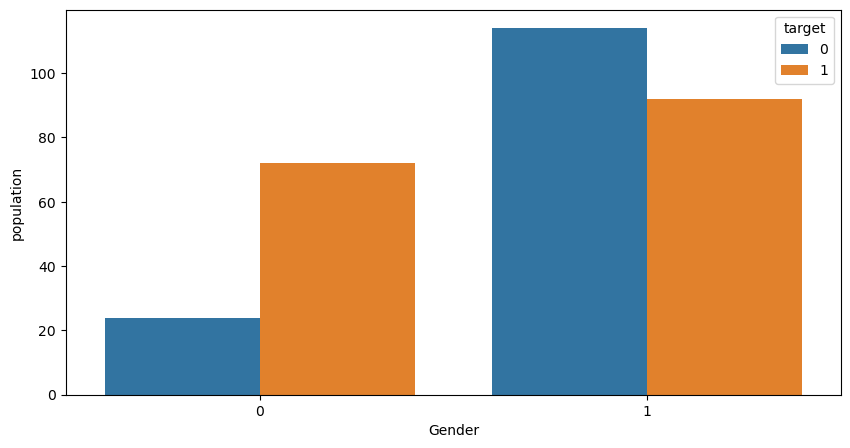

```python
plt.figure(figsize=(10, 5))
sns.countplot(x='sex', data=data, hue='target')
plt.xlabel('Gender')
plt.ylabel('population')

plt.show()
```

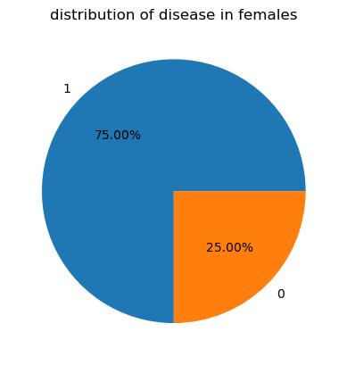

```python
female=data[data.sex==0]
female1=female.target.value_counts()
plt.pie(female1,labels=female1.index,autopct='%1.2f%%')
plt.title('distribution of disease in females')
plt.show()
```

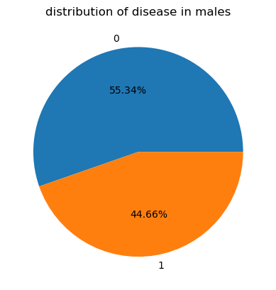

```python
male=data[data.sex==1]
male1=male.target.value_counts()
plt.pie(male1,labels=male1.index,autopct='%1.2f%%')
plt.title('distribution of disease in males')
plt.show()
```

### conclusion:

In case of females,the chances of having Malignant is higher.

### 4.distribution of disease according to age group

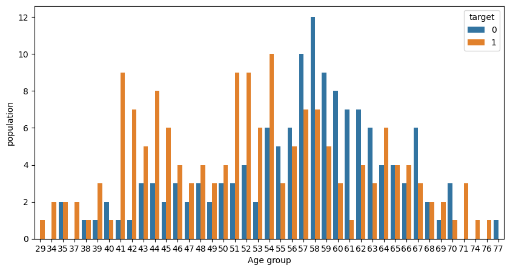

```python
plt.figure(figsize=(10, 5))
sns.countplot(x='age', data=data, hue='target')
plt.xlabel('Age group')
plt.ylabel('population')

plt.show()
```

### conclusion:

age group of 40-65 is more prone to heart diseases. In case of age group of 40-55,malignant condition is more dominant,whereas in age group 55-65 benign is more dominant.

### 5.Distribution of chest pain types

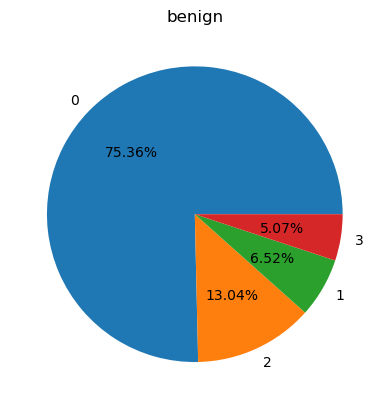

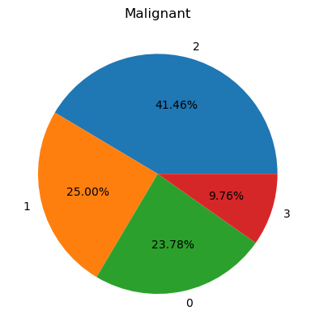

```python
begign=data[(data.target==0)]
cp1=begign.cp.value_counts()
plt.pie(cp1,labels=cp1.index,autopct='%1.2f%%')

plt.title('benign')
plt.show()

Malignant=data[(data.target==1)]
cp2=Malignant.cp.value_counts()
plt.pie(cp2,labels=cp2.index,autopct='%1.2f%%')
plt.title('Malignant')
plt.show()
```

### conclusion:

In begign codition,individual mostly suffer from typical angina.

### 6. blood pressure distribution

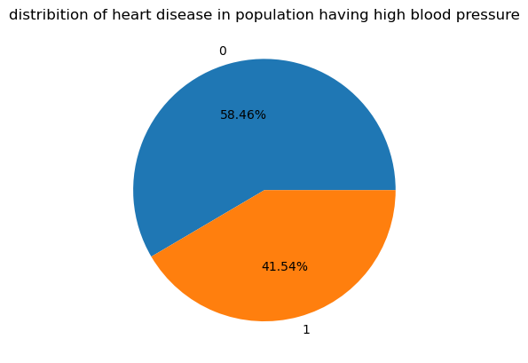

```python
bp=data[(data.trestbps>140) ]
df3=bp.target.value_counts()
plt.pie(df3,labels=df3.index,autopct='%1.2f%%')
plt.title('distribition of heart disease in population having high blood pressure')
plt.show()
```

### 7.cholestoral level distribution

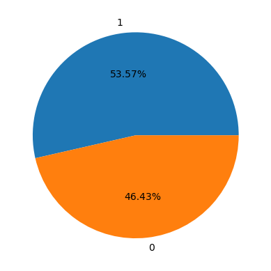

```python
chol=data[(data.chol>200) ]
df4=chol.target.value_counts()
plt.pie(df4,labels=df4.index,autopct='%1.2f%%')
plt.show()
```

### 8.fasting blood sugar distribution

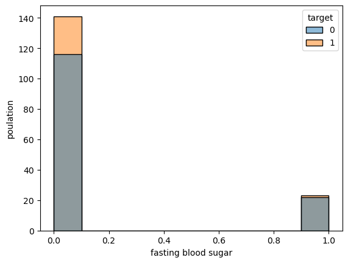

```python
sns.histplot(data=data, x='fbs',hue='target')
plt.xlabel('fasting blood sugar')
plt.ylabel('poulation')
plt.show()
```

### conclusion:

Even individuals with normal fasting sugar level are prone to heart diseases.

### 10.Exercise induced angina analysis

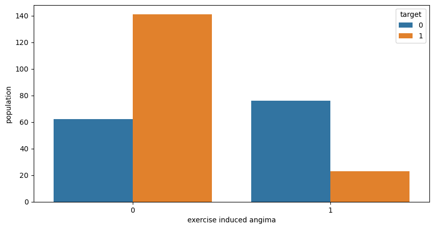

```python
plt.figure(figsize=(10, 5))
sns.countplot(x='exang', data=data, hue='target')
plt.xlabel('exercise induced angima')
plt.ylabel('population')
plt.show()
```

### conclusion:

individuals with negative result are more prone to Malignant whereas with positive result are more prone to benign

### 11.slope distribution

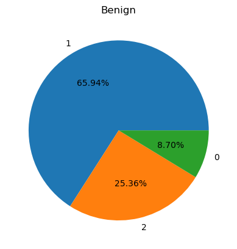

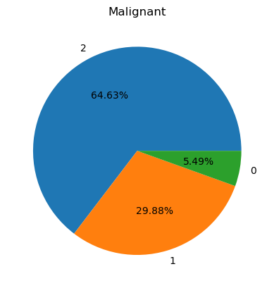

```python
s1=begign.slope.value_counts()
plt.pie(s1,labels=s1.index,autopct='%1.2f%%')
plt.title('Benign')
plt.show()

s2= Malignant.slope.value_counts()
plt.pie(s2,labels=s2.index,autopct='%1.2f%%')
plt.title('Malignant')
plt.show()
```

### conclusion:

individual having Downsloping slope are more prone to Malignant whereas those having Horizontal slope are more prone to Benign.

### 12. fluoroscopy results

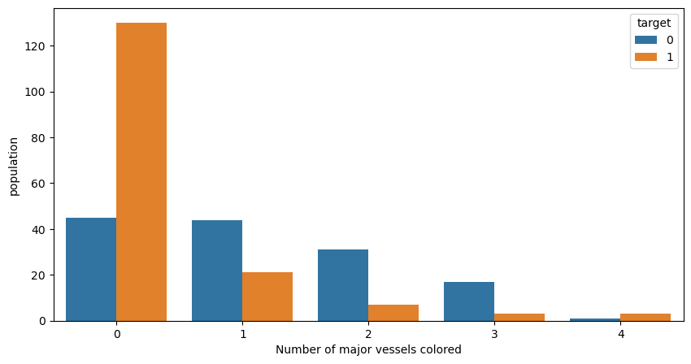

```python
plt.figure(figsize=(10, 5))
sns.countplot(x='ca', data=data, hue='target')
plt.xlabel('Number of major vessels colored')
plt.ylabel('population')
plt.show()
```

### conclusion:

If no vessel is coloured by fluoroscopy i.e.there are clots in major vessels ,the individual is prone to heart disease (Malignant being dominant)

### 13.Thallium scintigraphy

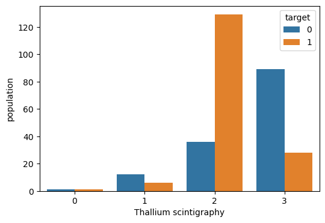

```python
plt.figure(figsize=(6,4))
sns.countplot(x='thal', data=data, hue='target')
plt.xlabel('Thallium scintigraphy')
plt.ylabel('population')
plt.show()
```

### conclusion:

All individual in the database have normal range in Thallium scintigraphy but individuals with 2 index are more prone to malignant whereas with index 3 are more prone to benign

### 14. Resting electrocardiographic results

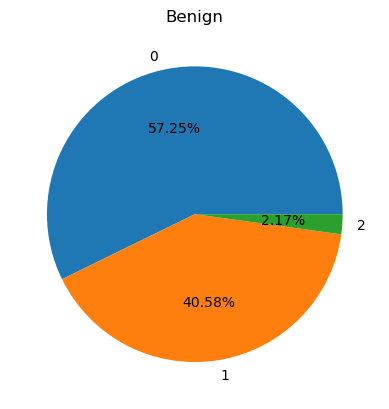

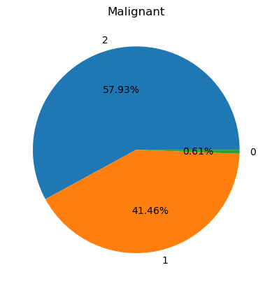

```python
r1=begign.restecg.value_counts()
plt.pie(r1,labels=r1.index,autopct='%1.2f%%')
plt.title('Benign')
plt.show()

r2= Malignant.restecg.value_counts()
plt.pie(r2,labels=s2.index,autopct='%1.2f%%')
plt.title('Malignant')
plt.show()
```

### 15.Heatmap

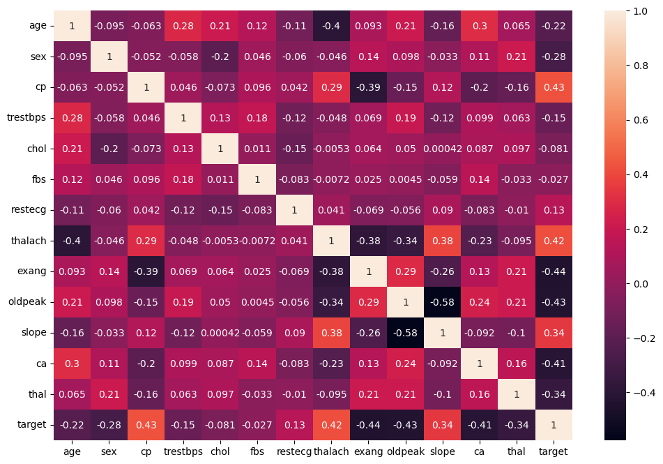

```python
corelation=data.corr()
plt.figure(figsize=(12, 8))
sns.heatmap(corelation,xticklabels=corelation.columns,yticklabels=corelation.columns,annot=True)
```

### conclusion:

#### 1.

age and maximum heart rate achieved have a strong correlation.

#### 2.

chest pain types and exercise induced angina have a strong correlation.

#### 3.

Maximum heart rate achieved and exercise induced angina have a strong correlation.

#### 4.

old peak and slope have a strong correlation.

### correlations

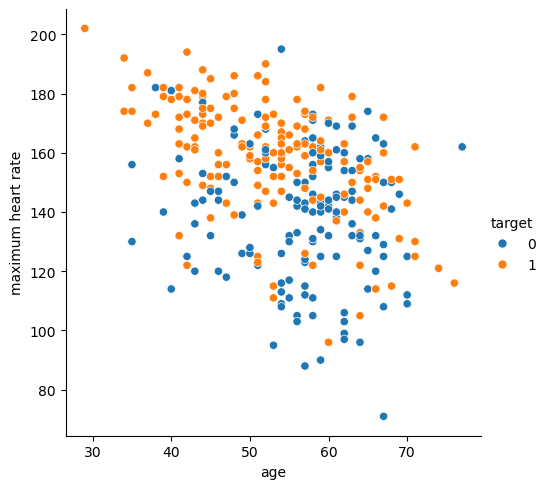

```python
sns.relplot(x='age', y='thalach', hue='target', data=data)
plt.xlabel('age')
plt.ylabel('maximum heart rate')
plt.show()
```

Age group 40-55 have higher heart rate and are more prone to malignant whereas 55-65 have lower heart rate and are more prone to benign.

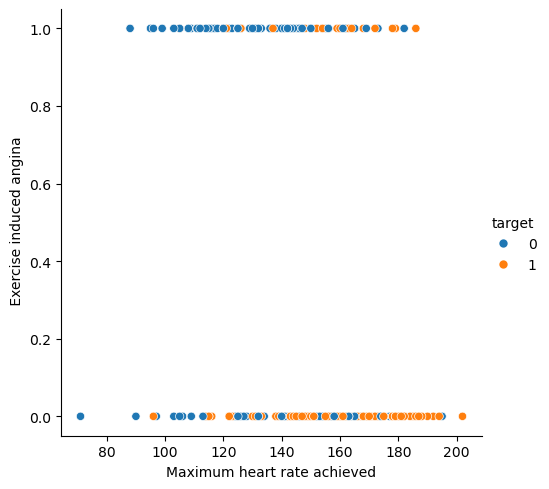

```python
sns.relplot(x='thalach', y='exang', hue='target', data=data)
plt.xlabel('Maximum heart rate achieved')
plt.ylabel(' Exercise induced angina')
plt.show()
```

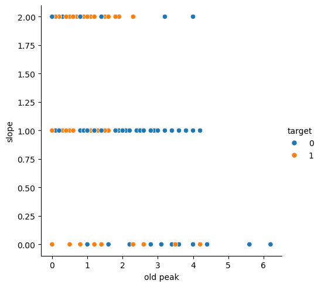

```python
sns.relplot(x='oldpeak', y='slope', hue='target', data=data)
plt.xlabel('old peak')
plt.ylabel('slope')
plt.show()
```

individuals having horizontal slope and old peak in range of[2,4] most likely to suffer from benign.